# Investigate Hollywood Movie Dataset

## Introduction

The Movie Database (TMDb) is a community built movie and TV database. Every piece of data has been added by their community, dating back to 2008. TMDb's strong international focus and breadth of data is largely unmatched. In this project of my Data Analysis, I am investigating a TMDb movies database file which has collection of important details of about 10k+ movies, including their details of budget, revenue, release dates, etc.

```python
import pandas as pd

#reading tmdb csv file and storing into variable
movie_data = pd.read_csv('tmdb-movies.csv')

#calling out first 50 rows (excluding headers) of tmdb database
movie_data.head(51)
```

|  | id | imdb_id | popularity | budget | revenue | original_title | cast | homepage | director | tagline | ... | overview | runtime | genres | production_companies | release_date | vote_count | vote_average | release_year | budget_adj | revenue_adj |
| --- | --- | --- | --- | --- | --- | --- | --- | --- | --- | --- | --- | --- | --- | --- | --- | --- | --- | --- | --- | --- | --- |
| 0 | 135397 | tt0369610 | 32.985763 | 150000000 | 1513528810 | Jurassic World | Chris Pratt\|Bryce Dallas Howard\|Irrfan Khan\|Vi... | http://www.jurassicworld.com/ | Colin Trevorrow | The park is open. | ... | Twenty-two years after the events of Jurassic ... | 124 | Action\|Adventure\|Science Fiction\|Thriller | Universal Studios\|Amblin Entertainment\|Legenda... | 6/9/15 | 5562 | 6.5 | 2015 | 1.379999e+08 | 1.392446e+09 |
| 1 | 76341 | tt1392190 | 28.419936 | 150000000 | 378436354 | Mad Max: Fury Road | Tom Hardy\|Charlize Theron\|Hugh Keays-Byrne\|Nic... | http://www.madmaxmovie.com/ | George Miller | What a Lovely Day. | ... | An apocalyptic story set in the furthest reach... | 120 | Action\|Adventure\|Science Fiction\|Thriller | Village Roadshow Pictures\|Kennedy Miller Produ... | 5/13/15 | 6185 | 7.1 | 2015 | 1.379999e+08 | 3.481613e+08 |
| 2 | 262500 | tt2908446 | 13.112507 | 110000000 | 295238201 | Insurgent | Shailene Woodley\|Theo James\|Kate Winslet\|Ansel... | http://www.thedivergentseries.movie/#insurgent | Robert Schwentke | One Choice Can Destroy You | ... | Beatrice Prior must confront her inner demons ... | 119 | Adventure\|Science Fiction\|Thriller | Summit Entertainment\|Mandeville Films\|Red Wago... | 3/18/15 | 2480 | 6.3 | 2015 | 1.012000e+08 | 2.716190e+08 |
| 3 | 140607 | tt2488496 | 11.173104 | 200000000 | 2068178225 | Star Wars: The Force Awakens | Harrison Ford\|Mark Hamill\|Carrie Fisher\|Adam D... | http://www.starwars.com/films/star-wars-episod... | J.J. Abrams | Every generation has a story. | ... | Thirty years after defeating the Galactic Empi... | 136 | Action\|Adventure\|Science Fiction\|Fantasy | Lucasfilm\|Truenorth Productions\|Bad Robot | 12/15/15 | 5292 | 7.5 | 2015 | 1.839999e+08 | 1.902723e+09 |
| 4 | 168259 | tt2820852 | 9.335014 | 190000000 | 1506249360 | Furious 7 | Vin Diesel\|Paul Walker\|Jason Statham\|Michelle ... | http://www.furious7.com/ | James Wan | Vengeance Hits Home | ... | Deckard Shaw seeks revenge against Dominic Tor... | 137 | Action\|Crime\|Thriller | Universal Pictures\|Original Film\|Media Rights ... | 4/1/15 | 2947 | 7.3 | 2015 | 1.747999e+08 | 1.385749e+09 |
| 5 | 281957 | tt1663202 | 9.110700 | 135000000 | 532950503 | The Revenant | Leonardo DiCaprio\|Tom Hardy\|Will Poulter\|Domhn... | http://www.foxmovies.com/movies/the-revenant | Alejandro González Iñárritu | (n. One who has returned, as if from the dead.) | ... | In the 1820s, a frontiersman, Hugh Glass, sets... | 156 | Western\|Drama\|Adventure\|Thriller | Regency Enterprises\|Appian Way\|CatchPlay\|Anony... | 12/25/15 | 3929 | 7.2 | 2015 | 1.241999e+08 | 4.903142e+08 |
| 6 | 87101 | tt1340138 | 8.654359 | 155000000 | 440603537 | Terminator Genisys | Arnold Schwarzenegger\|Jason Clarke\|Emilia Clar... | http://www.terminatormovie.com/ | Alan Taylor | Reset the future | ... | The year is 2029. John Connor, leader of the r... | 125 | Science Fiction\|Action\|Thriller\|Adventure | Paramount Pictures\|Skydance Productions | 6/23/15 | 2598 | 5.8 | 2015 | 1.425999e+08 | 4.053551e+08 |
| 7 | 286217 | tt3659388 | 7.667400 | 108000000 | 595380321 | The Martian | Matt Damon\|Jessica Chastain\|Kristen Wiig\|Jeff ... | http://www.foxmovies.com/movies/the-martian | Ridley Scott | Bring Him Home | ... | During a manned mission to Mars, Astronaut Mar... | 141 | Drama\|Adventure\|Science Fiction | Twentieth Century Fox Film Corporation\|Scott F... | 9/30/15 | 4572 | 7.6 | 2015 | 9.935996e+07 | 5.477497e+08 |
| 8 | 211672 | tt2293640 | 7.404165 | 74000000 | 1156730962 | Minions | Sandra Bullock\|Jon Hamm\|Michael Keaton\|Allison... | http://www.minionsmovie.com/ | Kyle Balda\|Pierre Coffin | Before Gru, they had a history of bad bosses | ... | Minions Stuart, Kevin and Bob are recruited by... | 91 | Family\|Animation\|Adventure\|Comedy | Universal Pictures\|Illumination Entertainment | 6/17/15 | 2893 | 6.5 | 2015 | 6.807997e+07 | 1.064192e+09 |
| 9 | 150540 | tt2096673 | 6.326804 | 175000000 | 853708609 | Inside Out | Amy Poehler\|Phyllis Smith\|Richard Kind\|Bill Ha... | http://movies.disney.com/inside-out | Pete Docter | Meet the little voices inside your head. | ... | Growing up can be a bumpy road, and it's no ex... | 94 | Comedy\|Animation\|Family | Walt Disney Pictures\|Pixar Animation Studios\|W... | 6/9/15 | 3935 | 8.0 | 2015 | 1.609999e+08 | 7.854116e+08 |
| 10 | 206647 | tt2379713 | 6.200282 | 245000000 | 880674609 | Spectre | Daniel Craig\|Christoph Waltz\|Léa Seydoux\|Ralp... | http://www.sonypictures.com/movies/spectre/ | Sam Mendes | A Plan No One Escapes | ... | A cryptic message from Bond’s past sends him... | 148 | Action\|Adventure\|Crime | Columbia Pictures\|Danjaq\|B24 | 10/26/15 | 3254 | 6.2 | 2015 | 2.253999e+08 | 8.102203e+08 |
| 11 | 76757 | tt1617661 | 6.189369 | 176000003 | 183987723 | Jupiter Ascending | Mila Kunis\|Channing Tatum\|Sean Bean\|Eddie Redm... | http://www.jupiterascending.com | Lana Wachowski\|Lilly Wachowski | Expand your universe. | ... | In a universe where human genetic material is ... | 124 | Science Fiction\|Fantasy\|Action\|Adventure | Village Roadshow Pictures\|Dune Entertainment\|A... | 2/4/15 | 1937 | 5.2 | 2015 | 1.619199e+08 | 1.692686e+08 |
| 12 | 264660 | tt0470752 | 6.118847 | 15000000 | 36869414 | Ex Machina | Domhnall Gleeson\|Alicia Vikander\|Oscar Isaac\|S... | http://exmachina-movie.com/ | Alex Garland | There is nothing more human than the will to s... | ... | Caleb, a 26 year old coder at the world's larg... | 108 | Drama\|Science Fiction | DNA Films\|Universal Pictures International (UP... | 1/21/15 | 2854 | 7.6 | 2015 | 1.379999e+07 | 3.391985e+07 |
| 13 | 257344 | tt2120120 | 5.984995 | 88000000 | 243637091 | Pixels | Adam Sandler\|Michelle Monaghan\|Peter Dinklage\|... | http://www.pixels-movie.com/ | Chris Columbus | Game On. | ... | Video game experts are recruited by the milita... | 105 | Action\|Comedy\|Science Fiction | Columbia Pictures\|Happy Madison Productions | 7/16/15 | 1575 | 5.8 | 2015 | 8.095996e+07 | 2.241460e+08 |
| 14 | 99861 | tt2395427 | 5.944927 | 280000000 | 1405035767 | Avengers: Age of Ultron | Robert Downey Jr.\|Chris Hemsworth\|Mark Ruffalo... | http://marvel.com/movies/movie/193/avengers_ag... | Joss Whedon | A New Age Has Come. | ... | When Tony Stark tries to jumpstart a dormant p... | 141 | Action\|Adventure\|Science Fiction | Marvel Studios\|Prime Focus\|Revolution Sun Studios | 4/22/15 | 4304 | 7.4 | 2015 | 2.575999e+08 | 1.292632e+09 |
| 15 | 273248 | tt3460252 | 5.898400 | 44000000 | 155760117 | The Hateful Eight | Samuel L. Jackson\|Kurt Russell\|Jennifer Jason ... | http://thehatefuleight.com/ | Quentin Tarantino | No one comes up here without a damn good reason. | ... | Bounty hunters seek shelter from a raging bliz... | 167 | Crime\|Drama\|Mystery\|Western | Double Feature Films\|The Weinstein Company\|Fil... | 12/25/15 | 2389 | 7.4 | 2015 | 4.047998e+07 | 1.432992e+08 |
| 16 | 260346 | tt2446042 | 5.749758 | 48000000 | 325771424 | Taken 3 | Liam Neeson\|Forest Whitaker\|Maggie Grace\|Famke... | http://www.taken3movie.com/ | Olivier Megaton | It Ends Here | ... | Ex-government operative Bryan Mills finds his ... | 109 | Crime\|Action\|Thriller | Twentieth Century Fox Film Corporation\|M6 Film... | 1/1/15 | 1578 | 6.1 | 2015 | 4.415998e+07 | 2.997096e+08 |
| 17 | 102899 | tt0478970 | 5.573184 | 130000000 | 518602163 | Ant-Man | Paul Rudd\|Michael Douglas\|Evangeline Lilly\|Cor... | http://marvel.com/movies/movie/180/ant-man | Peyton Reed | Heroes Don't Get Any Bigger | ... | Armed with the astonishing ability to shrink i... | 115 | Science Fiction\|Action\|Adventure | Marvel Studios | 7/14/15 | 3779 | 7.0 | 2015 | 1.195999e+08 | 4.771138e+08 |
| 18 | 150689 | tt1661199 | 5.556818 | 95000000 | 542351353 | Cinderella | Lily James\|Cate Blanchett\|Richard Madden\|Helen... | NaN | Kenneth Branagh | Midnight is just the beginning. | ... | When her father unexpectedly passes away, youn... | 112 | Romance\|Fantasy\|Family\|Drama | Walt Disney Pictures\|Genre Films\|Beagle Pug Fi... | 3/12/15 | 1495 | 6.8 | 2015 | 8.739996e+07 | 4.989630e+08 |
| 19 | 131634 | tt1951266 | 5.476958 | 160000000 | 650523427 | The Hunger Games: Mockingjay - Part 2 | Jennifer Lawrence\|Josh Hutcherson\|Liam Hemswor... | http://www.thehungergames.movie/ | Francis Lawrence | The fire will burn forever. | ... | With the nation of Panem in a full scale war, ... | 136 | War\|Adventure\|Science Fiction | Studio Babelsberg\|StudioCanal\|Lionsgate\|Walt D... | 11/18/15 | 2380 | 6.5 | 2015 | 1.471999e+08 | 5.984813e+08 |
| 20 | 158852 | tt1964418 | 5.462138 | 190000000 | 209035668 | Tomorrowland | Britt Robertson\|George Clooney\|Raffey Cassidy\|... | http://movies.disney.com/tomorrowland | Brad Bird | Imagine a world where nothing is impossible. | ... | Bound by a shared destiny, a bright, optimisti... | 130 | Action\|Family\|Science Fiction\|Adventure\|Mystery | Walt Disney Pictures\|Babieka\|A113 | 5/19/15 | 1899 | 6.2 | 2015 | 1.747999e+08 | 1.923127e+08 |
| 21 | 307081 | tt1798684 | 5.337064 | 30000000 | 91709827 | Southpaw | Jake Gyllenhaal\|Rachel McAdams\|Forest Whitaker... | NaN | Antoine Fuqua | Believe in Hope. | ... | Billy "The Great" Hope, the reigning junior mi... | 123 | Action\|Drama | Escape Artists\|Riche-Ludwig Productions | 6/15/15 | 1386 | 7.3 | 2015 | 2.759999e+07 | 8.437300e+07 |
| 22 | 254128 | tt2126355 | 4.907832 | 110000000 | 470490832 | San Andreas | Dwayne Johnson\|Alexandra Daddario\|Carla Gugino... | http://www.sanandreasmovie.com/ | Brad Peyton | A rescue pilot survived an earthquake, this is... | ... | In the aftermath of a massive earthquake in Ca... | 114 | Action\|Drama\|Thriller | New Line Cinema\|Village Roadshow Pictures\|Warn... | 5/27/15 | 2060 | 6.1 | 2015 | 1.012000e+08 | 4.328514e+08 |
| 23 | 216015 | tt2322441 | 4.710402 | 40000000 | 569651467 | Fifty Shades of Grey | Dakota Johnson\|Jamie Dornan\|Jennifer Ehle\|Eloi... | https://www.facebook.com/fiftyshadesofgreymovie | Sam Taylor-Johnson | Are you curious? | ... | When college senior Anastasia Steele steps in ... | 125 | Drama\|Romance | Focus Features\|Trigger Street Productions\|Mich... | 2/11/15 | 1865 | 5.3 | 2015 | 3.679998e+07 | 5.240791e+08 |
| 24 | 318846 | tt1596363 | 4.648046 | 28000000 | 133346506 | The Big Short | Christian Bale\|Steve Carell\|Ryan Gosling\|Brad ... | http://www.thebigshortmovie.com/ | Adam McKay | This is a true story. | ... | The men who made millions from a global econom... | 130 | Comedy\|Drama | Paramount Pictures\|Plan B Entertainment\|Regenc... | 12/11/15 | 1545 | 7.3 | 2015 | 2.575999e+07 | 1.226787e+08 |
| 25 | 177677 | tt2381249 | 4.566713 | 150000000 | 682330139 | Mission: Impossible - Rogue Nation | Tom Cruise\|Jeremy Renner\|Simon Pegg\|Rebecca Fe... | http://www.missionimpossible.com | Christopher McQuarrie | Desperate Times. Desperate Measures. | ... | Ethan and team take on their most impossible m... | 131 | Action | Paramount Pictures\|Skydance Productions\|China ... | 7/23/15 | 2349 | 7.1 | 2015 | 1.379999e+08 | 6.277435e+08 |
| 26 | 214756 | tt2637276 | 4.564549 | 68000000 | 215863606 | Ted 2 | Mark Wahlberg\|Seth MacFarlane\|Amanda Seyfried\|... | NaN | Seth MacFarlane | Ted is Coming, Again. | ... | Newlywed couple Ted and Tami-Lynn want to have... | 115 | Comedy | Universal Pictures\|Media Rights Capital\|Fuzzy ... | 6/25/15 | 1666 | 6.3 | 2015 | 6.255997e+07 | 1.985944e+08 |
| 27 | 207703 | tt2802144 | 4.503789 | 81000000 | 403802136 | Kingsman: The Secret Service | Taron Egerton\|Colin Firth\|Samuel L. Jackson\|Mi... | http://www.kingsmanmovie.com/ | Matthew Vaughn | Manners maketh man. | ... | The story of a super-secret spy organization t... | 130 | Crime\|Comedy\|Action\|Adventure | Twentieth Century Fox Film Corporation\|Marv Fi... | 1/24/15 | 3833 | 7.6 | 2015 | 7.451997e+07 | 3.714978e+08 |
| 28 | 314365 | tt1895587 | 4.062293 | 20000000 | 88346473 | Spotlight | Mark Ruffalo\|Michael Keaton\|Rachel McAdams\|Lie... | http://www.spotlightthefilm.com | Tom McCarthy | Break the story. Break the silence. | ... | The true story of how The Boston Globe uncover... | 128 | Drama\|Thriller\|History | Participant Media\|Open Road Films\|Anonymous Co... | 11/6/15 | 1559 | 7.8 | 2015 | 1.839999e+07 | 8.127872e+07 |
| 29 | 294254 | tt4046784 | 3.968891 | 61000000 | 311256926 | Maze Runner: The Scorch Trials | Dylan O'Brien\|Kaya Scodelario\|Thomas Brodie-Sa... | http://mazerunnermovies.com | Wes Ball | The Maze Was Just the Beginning. | ... | Thomas and his fellow Gladers face their great... | 132 | Action\|Science Fiction\|Thriller | Gotham Group\|Temple Hill Entertainment\|TSG Ent... | 9/9/15 | 1849 | 6.4 | 2015 | 5.611998e+07 | 2.863562e+08 |
| 30 | 280996 | tt3168230 | 3.927333 | 0 | 29355203 | Mr. Holmes | Ian McKellen\|Milo Parker\|Laura Linney\|Hattie M... | http://www.mrholmesfilm.com/ | Bill Condon | The man behind the myth | ... | The story is set in 1947, following a long-ret... | 103 | Mystery\|Drama | BBC Films\|See-Saw Films\|FilmNation Entertainme... | 6/19/15 | 425 | 6.4 | 2015 | 0.000000e+00 | 2.700677e+07 |
| 31 | 198184 | tt1823672 | 3.899557 | 49000000 | 102069268 | Chappie | Sharlto Copley\|Dev Patel\|Ninja\|Yolandi Visser\|... | http://www.chappie-movie.com | Neill Blomkamp | I am consciousness. I am alive. I am Chappie. | ... | Every child comes into the world full of promi... | 120 | Crime\|Action\|Science Fiction | Columbia Pictures\|Media Rights Capital\|Sony Pi... | 3/4/15 | 1990 | 6.6 | 2015 | 4.507998e+07 | 9.390369e+07 |
| 32 | 254470 | tt2848292 | 3.877764 | 29000000 | 287506194 | Pitch Perfect 2 | Anna Kendrick\|Rebel Wilson\|Hailee Steinfeld\|Br... | NaN | Elizabeth Banks | We're back pitches | ... | The Bellas are back, and they are better than ... | 115 | Comedy\|Music | Universal Pictures\|Gold Circle Films\|Brownston... | 5/7/15 | 1264 | 6.8 | 2015 | 2.667999e+07 | 2.645056e+08 |
| 33 | 296098 | tt3682448 | 3.648210 | 40000000 | 162610473 | Bridge of Spies | Tom Hanks\|Mark Rylance\|Amy Ryan\|Alan Alda\|Seba... | NaN | Steven Spielberg | In the shadow of war, one man showed the world... | ... | During the Cold War, the Soviet Union captures... | 141 | Thriller\|Drama | DreamWorks SKG\|Amblin Entertainment\|Studio Bab... | 10/15/15 | 1638 | 7.1 | 2015 | 3.679998e+07 | 1.496016e+08 |
| 34 | 257445 | tt1051904 | 3.644541 | 58000000 | 150170815 | Goosebumps | Jack Black\|Dylan Minnette\|Odeya Rush\|Amy Ryan\|... | http://www.goosebumps-movie.com/ | Rob Letterman | The stories are alive. | ... | A teenager teams up with the daughter of young... | 103 | Adventure\|Horror\|Comedy | Columbia Pictures\|Original Film\|Scholastic Ent... | 8/5/15 | 600 | 6.2 | 2015 | 5.335998e+07 | 1.381571e+08 |
| 35 | 264644 | tt3170832 | 3.557846 | 6000000 | 35401758 | Room | Brie Larson\|Jacob Tremblay\|Joan Allen\|Sean Bri... | http://www.roomthemovie.com | Lenny Abrahamson | Love knows no boundaries | ... | Jack is a young boy of 5 years old who has liv... | 117 | Drama\|Thriller | Element Pictures\|No Trace Camping\|A24\|Duperele... | 10/16/15 | 1520 | 8.0 | 2015 | 5.519998e+06 | 3.256960e+07 |
| 36 | 339527 | tt1291570 | 3.358321 | 0 | 22354572 | Solace | Abbie Cornish\|Jeffrey Dean Morgan\|Colin Farrel... | NaN | Afonso Poyart | A serial killer who can see your future, a psy... | ... | A psychic doctor, John Clancy, works with an F... | 101 | Crime\|Drama\|Mystery | Eden Rock Media\|FilmNation Entertainment\|Flynn... | 9/3/15 | 474 | 6.2 | 2015 | 0.000000e+00 | 2.056620e+07 |
| 37 | 105864 | tt1979388 | 3.339135 | 175000000 | 331926147 | The Good Dinosaur | Raymond Ochoa\|Jack Bright\|Jeffrey Wright\|Franc... | http://movies.disney.com/the-good-dinosaur | Peter Sohn | Little Arms With Big Attitude | ... | An epic journey into the world of dinosaurs wh... | 93 | Adventure\|Animation\|Comedy\|Family\|Fantasy | Walt Disney Pictures\|Pixar Animation Studios\|B... | 11/14/15 | 1087 | 6.6 | 2015 | 1.609999e+08 | 3.053719e+08 |
| 38 | 241554 | tt2199571 | 3.237370 | 50000000 | 71561644 | Run All Night | Liam Neeson\|Ed Harris\|Joel Kinnaman\|Boyd Holbr... | NaN | Jaume Collet-Serra | No sin goes unpunished | ... | Brooklyn mobster and prolific hit man Jimmy Co... | 114 | Action\|Crime\|Drama\|Mystery\|Thriller | Vertigo Entertainment\|Energy Entertainment\|Rat... | 3/11/15 | 814 | 6.3 | 2015 | 4.599998e+07 | 6.583668e+07 |
| 39 | 167073 | tt2381111 | 3.227329 | 11000000 | 62076141 | Brooklyn | Saoirse Ronan\|Domhnall Gleeson\|Emory Cohen\|Emi... | http://www.foxsearchlight.com/brooklyn/ | John Crowley | Two countries, two loves, one heart | ... | In 1950s Ireland and New York, young Ellis Lac... | 111 | Drama\|Romance | Wildgaze Films\|Irish Film Board\|Item 7\|Paralle... | 11/4/15 | 754 | 7.3 | 2015 | 1.012000e+07 | 5.711002e+07 |
| 40 | 277216 | tt1398426 | 3.202719 | 28000000 | 201634991 | Straight Outta Compton | O'Shea Jackson Jr.\|Corey Hawkins\|Jason Mitchel... | http://www.straightouttacompton.com/ | F. Gary Gray | The Story of N.W.A. | ... | In 1987, five young men, using brutally honest... | 147 | Drama\|Music | New Line Cinema\|Universal Pictures\|Legendary P... | 8/13/15 | 918 | 7.7 | 2015 | 2.575999e+07 | 1.855041e+08 |
| 41 | 274854 | tt1618442 | 3.080505 | 90000000 | 140396650 | The Last Witch Hunter | Vin Diesel\|Rose Leslie\|Michael Caine\|Elijah Wo... | http://www.thelastwitchhunter.movie/ | Breck Eisner | Hunt forever. | ... | The modern world holds many secrets, but by fa... | 106 | Fantasy\|Action\|Adventure | Summit Entertainment\|Atmosphere Entertainment ... | 10/21/15 | 879 | 5.6 | 2015 | 8.279996e+07 | 1.291649e+08 |
| 42 | 321697 | tt2080374 | 3.079522 | 30000000 | 34441873 | Steve Jobs | Michael Fassbender\|Kate Winslet\|Seth Rogen\|Kat... | http://www.stevejobsthefilm.com | Danny Boyle | NaN | ... | Set backstage at three iconic product launches... | 122 | History\|Drama | Universal Pictures\|Scott Rudin Productions\|Leg... | 10/9/15 | 1035 | 6.9 | 2015 | 2.759999e+07 | 3.168651e+07 |
| 43 | 203801 | tt1638355 | 3.053421 | 75000000 | 108145109 | The Man from U.N.C.L.E. | Henry Cavill\|Armie Hammer\|Alicia Vikander\|Eliz... | NaN | Guy Ritchie | Saving the world never goes out of style. | ... | At the height of the Cold War, a mysterious cr... | 116 | Comedy\|Action\|Adventure | Davis Entertainment\|Warner Bros.\|Wigram Produc... | 8/13/15 | 1548 | 7.0 | 2015 | 6.899997e+07 | 9.949346e+07 |
| 44 | 293863 | tt1655441 | 3.025852 | 25000000 | 42629776 | The Age of Adaline | Blake Lively\|Michiel Huisman\|Harrison Ford\|Ell... | http://theageofadalinemovie.com | Lee Toland Krieger | Love is timeless. | ... | After 29-year-old Adaline recovers from a near... | 112 | Fantasy\|Drama\|Romance | Lakeshore Entertainment\|Sidney Kimmel Entertai... | 4/16/15 | 1221 | 7.3 | 2015 | 2.299999e+07 | 3.921938e+07 |
| 45 | 325348 | tt3072482 | 3.023253 | 10000000 | 14333790 | Hardcore Henry | Sharlto Copley\|Haley Bennett\|Danila Kozlovskiy... | http://stxmovies.com/hardcorehenry/ | Ilya Naishuller | First they made him dangerous. Then they made ... | ... | Henry, a newly resurrected cyborg who must sav... | 97 | Action\|Adventure\|Science Fiction | Bazelevs Production\|Versus Pictures | 9/12/15 | 396 | 5.9 | 2015 | 9.199996e+06 | 1.318708e+07 |
| 46 | 228161 | tt2224026 | 2.976436 | 135000000 | 368871007 | Home | Jim Parsons\|Rihanna\|Steve Martin\|Jennifer Lope... | http://www.meettheboov.com/ | Tim Johnson | Worlds Collide | ... | When Earth is taken over by the overly-confide... | 94 | Fantasy\|Comedy\|Animation\|Science Fiction\|Family | Twentieth Century Fox Film Corporation\|DreamWo... | 3/18/15 | 1060 | 6.9 | 2015 | 1.241999e+08 | 3.393612e+08 |
| 47 | 286565 | tt3622592 | 2.968254 | 12000000 | 85512300 | Paper Towns | Nat Wolff\|Cara Delevingne\|Halston Sage\|Justice... | NaN | Jake Schreier | Get Lost. Get Found. | ... | Quentin Jacobsen has spent a lifetime loving t... | 109 | Drama\|Mystery\|Romance | Fox 2000 Pictures | 7/9/15 | 1252 | 6.2 | 2015 | 1.104000e+07 | 7.867128e+07 |
| 48 | 265208 | tt2231253 | 2.932340 | 30000000 | 0 | Wild Card | Jason Statham\|Michael Angarano\|Milo Ventimigli... | NaN | Simon West | Never bet against a man with a killer hand. | ... | When a Las Vegas bodyguard with lethal skills ... | 92 | Thriller\|Crime\|Drama | Current Entertainment\|Lionsgate\|Sierra / Affin... | 1/14/15 | 481 | 5.3 | 2015 | 2.759999e+07 | 0.000000e+00 |
| 49 | 254320 | tt3464902 | 2.885126 | 4000000 | 9064511 | The Lobster | Colin Farrell\|Rachel Weisz\|Léa Seydoux\|John C... | http://tickets.picturehouseentertainment.co.uk... | Yorgos Lanthimos | An unconventional love story... | ... | In a dystopian near future, single people, acc... | 118 | Thriller\|Comedy\|Drama\|Romance\|Science Fiction | Haut et Court\|Eurimages\|Lemming Film\|Element P... | 10/8/15 | 638 | 6.6 | 2015 | 3.679998e+06 | 8.339346e+06 |
| 50 | 258480 | tt2402927 | 2.883233 | 11800000 | 40272135 | Carol | Cate Blanchett\|Rooney Mara\|Kyle Chandler\|Sarah... | http://carolfilm.com/ | Todd Haynes | Some people change your life forever. | ... | In 1950s New York, a department-store clerk wh... | 118 | Romance\|Drama | Killer Films\|Film4\|Number 9 Films | 11/20/15 | 562 | 7.1 | 2015 | 1.085600e+07 | 3.705035e+07 |

51 rows × 21 columns

### What can we say about the dataset?

- The vote count for each movie is not similar, for example, the movie `Mad Max : Fury Road` has `6k+` votes while `The Last Witch Hunter` has only `879 votes` (as seen above). Since the votes of the movies vary so much the `vote_average` column also is effected by it. So we cannot calculate or assume that movie with highest votes or rating was more successful since the voters of each film vary.
- The columns `budget`, `revenue`, `budget_adj`, `revenue_adj` has not given us the currency. So by default we will assume this to be doller.

### What Questions can be brainstormed?

Looking at this database, we can think about-

- Which genres are most popular from year to year? What kinds of properties are associated with movies that have high revenues
- Which movie gained the most profit (or which movie has been the people's favourite?)
- Which year the movies made the most profit?

### What needs to be Wrangled & Cleaned?

Based on the questions above, first of all we have to find out which columns in the datasets can be useful in answering these questions. After pondering about it, we have to remove the non-useful columns so that the dataframes should not look messy and can be easily understandable.

- As you can see in this dataset of movies there are lots of movies where the budget or revenue have a value of '0' which means that the values of those variables of those movies has not been recorded. Calculating the profits of these movies would lead to inappropriate results. So we need to delete these rows.
- Also this dataset has some duplicate rows. We have to clean that too for appropriate results.
- We will calculate the average runtime of the movies so in that case if we have a runtime of a movie '0' then we need to replace it with `NaN`.
- The `release_date` column must be converted into date format.
- Checking if all columns are in the desired data type, if not then we have to change it.
- Mentioning the country currency in the desired columns.
- Finally, we will also remove unnecessory columns such as ` 'id', 'imdb_id', 'popularity', 'budget_adj', 'revenue_adj', 'homepage', 'keywords', 'overview', 'production_companies', 'vote_count' and 'vote_average` (Data trimming).

### Questions to be Answered

1. General questions about the dataset.
1. Which movie earns the most and least profit?
2. Which movie had the greatest and least runtime?
3. Which movie had the greatest and least budget?
4. Which movie had the greatest and least revenue?
5. What is the average runtime of all movies?
6. In which year we had the most movies making profits?
2. What are the similar characteristics does the most profitable movie have?

3. Average duration of movies.
4. Average Budget.
5. Average revenue.
6. Average profits.
7. Which director directed most films?
8. Whcih cast has appeared the most?
9. Which genre were more successful?
10. Which month released highest number of movies in all of the years? And which month made the most profit?

## Data Cleaning

First, lets clean up the columns. We will only keep the columns we need and remove the rest of them.

Columns to delete - `id, imdb_id, popularity, budget_adj, revenue_adj, homepage, keywords, overview, production_companies, vote_count and vote_average.`

```python
#importing all the nescessory libraries
import numpy as np
from matplotlib import pyplot as plt
import seaborn as sns

# a list of movies that needs to be deleted
del_col = [ 'id', 'imdb_id', 'popularity', 'budget_adj', 'revenue_adj', 'homepage', 'keywords', 'overview', 'production_companies', 'vote_count', 'vote_average']

#deleting the columns from the database
movie_data = movie_data.drop(del_col, 1)
#now take a look at this new dataset
movie_data.head()
```

|  | budget | revenue | original_title | cast | director | tagline | runtime | genres | release_date | release_year |
| --- | --- | --- | --- | --- | --- | --- | --- | --- | --- | --- |
| 0 | 150000000 | 1513528810 | Jurassic World | Chris Pratt\|Bryce Dallas Howard\|Irrfan Khan\|Vi... | Colin Trevorrow | The park is open. | 124 | Action\|Adventure\|Science Fiction\|Thriller | 6/9/15 | 2015 |
| 1 | 150000000 | 378436354 | Mad Max: Fury Road | Tom Hardy\|Charlize Theron\|Hugh Keays-Byrne\|Nic... | George Miller | What a Lovely Day. | 120 | Action\|Adventure\|Science Fiction\|Thriller | 5/13/15 | 2015 |
| 2 | 110000000 | 295238201 | Insurgent | Shailene Woodley\|Theo James\|Kate Winslet\|Ansel... | Robert Schwentke | One Choice Can Destroy You | 119 | Adventure\|Science Fiction\|Thriller | 3/18/15 | 2015 |
| 3 | 200000000 | 2068178225 | Star Wars: The Force Awakens | Harrison Ford\|Mark Hamill\|Carrie Fisher\|Adam D... | J.J. Abrams | Every generation has a story. | 136 | Action\|Adventure\|Science Fiction\|Fantasy | 12/15/15 | 2015 |
| 4 | 190000000 | 1506249360 | Furious 7 | Vin Diesel\|Paul Walker\|Jason Statham\|Michelle ... | James Wan | Vengeance Hits Home | 137 | Action\|Crime\|Thriller | 4/1/15 | 2015 |

Now the original dataset is more clear and easily understandable. Our next step will be to remove the duplicate entries (if any). Now lets clean for any duplicate rows.

```python
movie_data.drop_duplicates(keep = 'first', inplace = True)
movie_data
```

|  | budget | revenue | original_title | cast | director | tagline | runtime | genres | release_date | release_year |
| --- | --- | --- | --- | --- | --- | --- | --- | --- | --- | --- |
| 0 | 150000000 | 1513528810 | Jurassic World | Chris Pratt\|Bryce Dallas Howard\|Irrfan Khan\|Vi... | Colin Trevorrow | The park is open. | 124 | Action\|Adventure\|Science Fiction\|Thriller | 6/9/15 | 2015 |
| 1 | 150000000 | 378436354 | Mad Max: Fury Road | Tom Hardy\|Charlize Theron\|Hugh Keays-Byrne\|Nic... | George Miller | What a Lovely Day. | 120 | Action\|Adventure\|Science Fiction\|Thriller | 5/13/15 | 2015 |
| 2 | 110000000 | 295238201 | Insurgent | Shailene Woodley\|Theo James\|Kate Winslet\|Ansel... | Robert Schwentke | One Choice Can Destroy You | 119 | Adventure\|Science Fiction\|Thriller | 3/18/15 | 2015 |
| 3 | 200000000 | 2068178225 | Star Wars: The Force Awakens | Harrison Ford\|Mark Hamill\|Carrie Fisher\|Adam D... | J.J. Abrams | Every generation has a story. | 136 | Action\|Adventure\|Science Fiction\|Fantasy | 12/15/15 | 2015 |
| 4 | 190000000 | 1506249360 | Furious 7 | Vin Diesel\|Paul Walker\|Jason Statham\|Michelle ... | James Wan | Vengeance Hits Home | 137 | Action\|Crime\|Thriller | 4/1/15 | 2015 |
| 5 | 135000000 | 532950503 | The Revenant | Leonardo DiCaprio\|Tom Hardy\|Will Poulter\|Domhn... | Alejandro González Iñárritu | (n. One who has returned, as if from the dead.) | 156 | Western\|Drama\|Adventure\|Thriller | 12/25/15 | 2015 |
| 6 | 155000000 | 440603537 | Terminator Genisys | Arnold Schwarzenegger\|Jason Clarke\|Emilia Clar... | Alan Taylor | Reset the future | 125 | Science Fiction\|Action\|Thriller\|Adventure | 6/23/15 | 2015 |
| 7 | 108000000 | 595380321 | The Martian | Matt Damon\|Jessica Chastain\|Kristen Wiig\|Jeff ... | Ridley Scott | Bring Him Home | 141 | Drama\|Adventure\|Science Fiction | 9/30/15 | 2015 |
| 8 | 74000000 | 1156730962 | Minions | Sandra Bullock\|Jon Hamm\|Michael Keaton\|Allison... | Kyle Balda\|Pierre Coffin | Before Gru, they had a history of bad bosses | 91 | Family\|Animation\|Adventure\|Comedy | 6/17/15 | 2015 |
| 9 | 175000000 | 853708609 | Inside Out | Amy Poehler\|Phyllis Smith\|Richard Kind\|Bill Ha... | Pete Docter | Meet the little voices inside your head. | 94 | Comedy\|Animation\|Family | 6/9/15 | 2015 |
| 10 | 245000000 | 880674609 | Spectre | Daniel Craig\|Christoph Waltz\|Léa Seydoux\|Ralp... | Sam Mendes | A Plan No One Escapes | 148 | Action\|Adventure\|Crime | 10/26/15 | 2015 |
| 11 | 176000003 | 183987723 | Jupiter Ascending | Mila Kunis\|Channing Tatum\|Sean Bean\|Eddie Redm... | Lana Wachowski\|Lilly Wachowski | Expand your universe. | 124 | Science Fiction\|Fantasy\|Action\|Adventure | 2/4/15 | 2015 |
| 12 | 15000000 | 36869414 | Ex Machina | Domhnall Gleeson\|Alicia Vikander\|Oscar Isaac\|S... | Alex Garland | There is nothing more human than the will to s... | 108 | Drama\|Science Fiction | 1/21/15 | 2015 |
| 13 | 88000000 | 243637091 | Pixels | Adam Sandler\|Michelle Monaghan\|Peter Dinklage\|... | Chris Columbus | Game On. | 105 | Action\|Comedy\|Science Fiction | 7/16/15 | 2015 |
| 14 | 280000000 | 1405035767 | Avengers: Age of Ultron | Robert Downey Jr.\|Chris Hemsworth\|Mark Ruffalo... | Joss Whedon | A New Age Has Come. | 141 | Action\|Adventure\|Science Fiction | 4/22/15 | 2015 |
| 15 | 44000000 | 155760117 | The Hateful Eight | Samuel L. Jackson\|Kurt Russell\|Jennifer Jason ... | Quentin Tarantino | No one comes up here without a damn good reason. | 167 | Crime\|Drama\|Mystery\|Western | 12/25/15 | 2015 |
| 16 | 48000000 | 325771424 | Taken 3 | Liam Neeson\|Forest Whitaker\|Maggie Grace\|Famke... | Olivier Megaton | It Ends Here | 109 | Crime\|Action\|Thriller | 1/1/15 | 2015 |
| 17 | 130000000 | 518602163 | Ant-Man | Paul Rudd\|Michael Douglas\|Evangeline Lilly\|Cor... | Peyton Reed | Heroes Don't Get Any Bigger | 115 | Science Fiction\|Action\|Adventure | 7/14/15 | 2015 |
| 18 | 95000000 | 542351353 | Cinderella | Lily James\|Cate Blanchett\|Richard Madden\|Helen... | Kenneth Branagh | Midnight is just the beginning. | 112 | Romance\|Fantasy\|Family\|Drama | 3/12/15 | 2015 |
| 19 | 160000000 | 650523427 | The Hunger Games: Mockingjay - Part 2 | Jennifer Lawrence\|Josh Hutcherson\|Liam Hemswor... | Francis Lawrence | The fire will burn forever. | 136 | War\|Adventure\|Science Fiction | 11/18/15 | 2015 |
| 20 | 190000000 | 209035668 | Tomorrowland | Britt Robertson\|George Clooney\|Raffey Cassidy\|... | Brad Bird | Imagine a world where nothing is impossible. | 130 | Action\|Family\|Science Fiction\|Adventure\|Mystery | 5/19/15 | 2015 |
| 21 | 30000000 | 91709827 | Southpaw | Jake Gyllenhaal\|Rachel McAdams\|Forest Whitaker... | Antoine Fuqua | Believe in Hope. | 123 | Action\|Drama | 6/15/15 | 2015 |
| 22 | 110000000 | 470490832 | San Andreas | Dwayne Johnson\|Alexandra Daddario\|Carla Gugino... | Brad Peyton | A rescue pilot survived an earthquake, this is... | 114 | Action\|Drama\|Thriller | 5/27/15 | 2015 |
| 23 | 40000000 | 569651467 | Fifty Shades of Grey | Dakota Johnson\|Jamie Dornan\|Jennifer Ehle\|Eloi... | Sam Taylor-Johnson | Are you curious? | 125 | Drama\|Romance | 2/11/15 | 2015 |
| 24 | 28000000 | 133346506 | The Big Short | Christian Bale\|Steve Carell\|Ryan Gosling\|Brad ... | Adam McKay | This is a true story. | 130 | Comedy\|Drama | 12/11/15 | 2015 |
| 25 | 150000000 | 682330139 | Mission: Impossible - Rogue Nation | Tom Cruise\|Jeremy Renner\|Simon Pegg\|Rebecca Fe... | Christopher McQuarrie | Desperate Times. Desperate Measures. | 131 | Action | 7/23/15 | 2015 |
| 26 | 68000000 | 215863606 | Ted 2 | Mark Wahlberg\|Seth MacFarlane\|Amanda Seyfried\|... | Seth MacFarlane | Ted is Coming, Again. | 115 | Comedy | 6/25/15 | 2015 |
| 27 | 81000000 | 403802136 | Kingsman: The Secret Service | Taron Egerton\|Colin Firth\|Samuel L. Jackson\|Mi... | Matthew Vaughn | Manners maketh man. | 130 | Crime\|Comedy\|Action\|Adventure | 1/24/15 | 2015 |
| 28 | 20000000 | 88346473 | Spotlight | Mark Ruffalo\|Michael Keaton\|Rachel McAdams\|Lie... | Tom McCarthy | Break the story. Break the silence. | 128 | Drama\|Thriller\|History | 11/6/15 | 2015 |
| 29 | 61000000 | 311256926 | Maze Runner: The Scorch Trials | Dylan O'Brien\|Kaya Scodelario\|Thomas Brodie-Sa... | Wes Ball | The Maze Was Just the Beginning. | 132 | Action\|Science Fiction\|Thriller | 9/9/15 | 2015 |
| ... | ... | ... | ... | ... | ... | ... | ... | ... | ... | ... |
| 10836 | 0 | 0 | Walk Don't Run | Cary Grant\|Samantha Eggar\|Jim Hutton\|John Stan... | Charles Walters | Run, don't walk to see Walk, Don't Run. | 114 | Comedy\|Romance | 1/1/66 | 1966 |
| 10837 | 0 | 0 | The Blue Max | George Peppard\|James Mason\|Ursula Andress\|Jere... | John Guillermin | There was no quiet on the Western Front! | 156 | War\|Action\|Adventure\|Drama | 6/21/66 | 1966 |
| 10838 | 0 | 0 | The Professionals | Burt Lancaster\|Lee Marvin\|Robert Ryan\|Woody St... | Richard Brooks | Rough, tough and ready. | 117 | Action\|Adventure\|Western | 11/1/66 | 1966 |
| 10839 | 0 | 0 | It's the Great Pumpkin, Charlie Brown | Christopher Shea\|Sally Dryer\|Kathy Steinberg\|A... | Bill Melendez | Every year he rises from the pumpkin patch... | 25 | Family\|Animation | 10/27/66 | 1966 |
| 10840 | 0 | 0 | Funeral in Berlin | Michael Caine\|Paul Hubschmid\|Oskar Homolka\|Eva... | Guy Hamilton | NaN | 102 | Thriller | 12/22/66 | 1966 |
| 10841 | 75000 | 0 | The Shooting | Will Hutchins\|Millie Perkins\|Jack Nicholson\|Wa... | Monte Hellman | Suspenseful desert pursuit in the "High Noon" ... | 82 | Western | 10/23/66 | 1966 |
| 10842 | 0 | 0 | Winnie the Pooh and the Honey Tree | Sterling Holloway\|Junius Matthews\|Sebastian Ca... | Wolfgang Reitherman | NaN | 25 | Animation\|Family | 1/1/66 | 1966 |
| 10843 | 0 | 0 | Khartoum | Charlton Heston\|Laurence Olivier\|Richard Johns... | Basil Dearden\|Eliot Elisofon | Where the Nile divides, the great Cinerama adv... | 134 | Adventure\|Drama\|War\|History\|Action | 6/9/66 | 1966 |
| 10844 | 0 | 0 | Our Man Flint | James Coburn\|Lee J. Cobb\|Gila Golan\|Edward Mul... | Daniel Mann | The ORIGINAL man of mystery! | 108 | Adventure\|Comedy\|Fantasy\|Science Fiction | 1/16/66 | 1966 |
| 10845 | 0 | 0 | Carry On Cowboy | Sid James\|Jim Dale\|Angela Douglas\|Kenneth Will... | Gerald Thomas | How the west was lost! | 93 | Comedy\|Western | 3/1/66 | 1966 |
| 10846 | 0 | 0 | Dracula: Prince of Darkness | Christopher Lee\|Barbara Shelley\|Andrew Keir\|Fr... | Terence Fisher | DEAD for Ten Years DRACULA, Prince of Darkness... | 90 | Horror | 1/9/66 | 1966 |
| 10847 | 0 | 0 | Island of Terror | Peter Cushing\|Edward Judd\|Carole Gray\|Eddie By... | Terence Fisher | How could they stop the devouring death...that... | 89 | Science Fiction\|Horror | 6/20/66 | 1966 |
| 10848 | 5115000 | 12000000 | Fantastic Voyage | Stephen Boyd\|Raquel Welch\|Edmond O'Brien\|Donal... | Richard Fleischer | A Fantastic and Spectacular Voyage... Through ... | 100 | Adventure\|Science Fiction | 8/24/66 | 1966 |
| 10849 | 0 | 0 | Gambit | Michael Caine\|Shirley MacLaine\|Herbert Lom\|Joh... | Ronald Neame | Shirley MacLaine raises Michael Caine! | 109 | Action\|Comedy\|Crime | 12/16/66 | 1966 |
| 10850 | 0 | 0 | Harper | Paul Newman\|Lauren Bacall\|Julie Harris\|Arthur ... | Jack Smight | Harper takes a case - and the payoff is murder. | 121 | Action\|Drama\|Thriller\|Crime\|Mystery | 2/23/66 | 1966 |
| 10851 | 0 | 0 | Born Free | Virginia McKenna\|Bill Travers\|Geoffrey Keen\|Pe... | James Hill | From The Pages Of The Beloved Best Seller... A... | 95 | Adventure\|Drama\|Action\|Family\|Foreign | 6/22/66 | 1966 |
| 10852 | 0 | 0 | A Big Hand for the Little Lady | Henry Fonda\|Joanne Woodward\|Jason Robards\|Paul... | Fielder Cook | All the action you can take...all the adventur... | 95 | Western | 5/31/66 | 1966 |
| 10853 | 0 | 0 | Alfie | Michael Caine\|Shelley Winters\|Millicent Martin... | Lewis Gilbert | Is any man an Alfie? Ask any girl! | 114 | Comedy\|Drama\|Romance | 3/29/66 | 1966 |
| 10854 | 0 | 0 | The Chase | Marlon Brando\|Jane Fonda\|Robert Redford\|E.G. M... | Arthur Penn | The chase is on! | 135 | Thriller\|Drama\|Crime | 2/17/66 | 1966 |
| 10855 | 700000 | 0 | The Ghost & Mr. Chicken | Don Knotts\|Joan Staley\|Liam Redmond\|Dick Sarge... | Alan Rafkin | G-G-GUARANTEED! YOU'LL BE SCARED UNTIL YOU LAU... | 90 | Comedy\|Family\|Mystery\|Romance | 1/20/66 | 1966 |
| 10856 | 0 | 0 | The Ugly Dachshund | Dean Jones\|Suzanne Pleshette\|Charles Ruggles\|K... | Norman Tokar | A HAPPY HONEYMOON GOES TO THE DOGS!...When a G... | 93 | Comedy\|Drama\|Family | 2/16/66 | 1966 |
| 10857 | 0 | 0 | Nevada Smith | Steve McQueen\|Karl Malden\|Brian Keith\|Arthur K... | Henry Hathaway | Some called him savage- and some called him sa... | 128 | Action\|Western | 6/10/66 | 1966 |
| 10858 | 0 | 0 | The Russians Are Coming, The Russians Are Coming | Carl Reiner\|Eva Marie Saint\|Alan Arkin\|Brian K... | Norman Jewison | IT'S A PLOT! ...to make the world die laughing!! | 126 | Comedy\|War | 5/25/66 | 1966 |
| 10859 | 0 | 0 | Seconds | Rock Hudson\|Salome Jens\|John Randolph\|Will Gee... | John Frankenheimer | NaN | 100 | Mystery\|Science Fiction\|Thriller\|Drama | 10/5/66 | 1966 |
| 10860 | 0 | 0 | Carry On Screaming! | Kenneth Williams\|Jim Dale\|Harry H. Corbett\|Joa... | Gerald Thomas | Carry On Screaming with the Hilarious CARRY ON... | 87 | Comedy | 5/20/66 | 1966 |
| 10861 | 0 | 0 | The Endless Summer | Michael Hynson\|Robert August\|Lord 'Tally Ho' B... | Bruce Brown | NaN | 95 | Documentary | 6/15/66 | 1966 |
| 10862 | 0 | 0 | Grand Prix | James Garner\|Eva Marie Saint\|Yves Montand\|Tosh... | John Frankenheimer | Cinerama sweeps YOU into a drama of speed and ... | 176 | Action\|Adventure\|Drama | 12/21/66 | 1966 |
| 10863 | 0 | 0 | Beregis Avtomobilya | Innokentiy Smoktunovskiy\|Oleg Efremov\|Georgi Z... | Eldar Ryazanov | NaN | 94 | Mystery\|Comedy | 1/1/66 | 1966 |
| 10864 | 0 | 0 | What's Up, Tiger Lily? | Tatsuya Mihashi\|Akiko Wakabayashi\|Mie Hama\|Joh... | Woody Allen | WOODY ALLEN STRIKES BACK! | 80 | Action\|Comedy | 11/2/66 | 1966 |
| 10865 | 19000 | 0 | Manos: The Hands of Fate | Harold P. Warren\|Tom Neyman\|John Reynolds\|Dian... | Harold P. Warren | It's Shocking! It's Beyond Your Imagination! | 74 | Horror | 11/15/66 | 1966 |

10865 rows × 10 columns

Now, lets figure out which movies have a value of `'0'` in their `budget` or `revenue`, and then we will delete those movies from dataset.

```python
check_row = ['budget', 'revenue']    #list of column names that needs to be checked

#this will replace the value of '0' to NaN of columns given in the list
movie_data[check_row] = movie_data[check_row].replace(0, np.NaN)

#now we will drop any row which has NaN values in any of the column of the list (check_row)
movie_data.dropna(subset = check_row, inplace = True)

#showing the dataset
movie_data
```

|  | budget | revenue | original_title | cast | director | tagline | runtime | genres | release_date | release_year |
| --- | --- | --- | --- | --- | --- | --- | --- | --- | --- | --- |
| 0 | 150000000.0 | 1.513529e+09 | Jurassic World | Chris Pratt\|Bryce Dallas Howard\|Irrfan Khan\|Vi... | Colin Trevorrow | The park is open. | 124 | Action\|Adventure\|Science Fiction\|Thriller | 6/9/15 | 2015 |
| 1 | 150000000.0 | 3.784364e+08 | Mad Max: Fury Road | Tom Hardy\|Charlize Theron\|Hugh Keays-Byrne\|Nic... | George Miller | What a Lovely Day. | 120 | Action\|Adventure\|Science Fiction\|Thriller | 5/13/15 | 2015 |
| 2 | 110000000.0 | 2.952382e+08 | Insurgent | Shailene Woodley\|Theo James\|Kate Winslet\|Ansel... | Robert Schwentke | One Choice Can Destroy You | 119 | Adventure\|Science Fiction\|Thriller | 3/18/15 | 2015 |
| 3 | 200000000.0 | 2.068178e+09 | Star Wars: The Force Awakens | Harrison Ford\|Mark Hamill\|Carrie Fisher\|Adam D... | J.J. Abrams | Every generation has a story. | 136 | Action\|Adventure\|Science Fiction\|Fantasy | 12/15/15 | 2015 |
| 4 | 190000000.0 | 1.506249e+09 | Furious 7 | Vin Diesel\|Paul Walker\|Jason Statham\|Michelle ... | James Wan | Vengeance Hits Home | 137 | Action\|Crime\|Thriller | 4/1/15 | 2015 |
| 5 | 135000000.0 | 5.329505e+08 | The Revenant | Leonardo DiCaprio\|Tom Hardy\|Will Poulter\|Domhn... | Alejandro González Iñárritu | (n. One who has returned, as if from the dead.) | 156 | Western\|Drama\|Adventure\|Thriller | 12/25/15 | 2015 |
| 6 | 155000000.0 | 4.406035e+08 | Terminator Genisys | Arnold Schwarzenegger\|Jason Clarke\|Emilia Clar... | Alan Taylor | Reset the future | 125 | Science Fiction\|Action\|Thriller\|Adventure | 6/23/15 | 2015 |
| 7 | 108000000.0 | 5.953803e+08 | The Martian | Matt Damon\|Jessica Chastain\|Kristen Wiig\|Jeff ... | Ridley Scott | Bring Him Home | 141 | Drama\|Adventure\|Science Fiction | 9/30/15 | 2015 |
| 8 | 74000000.0 | 1.156731e+09 | Minions | Sandra Bullock\|Jon Hamm\|Michael Keaton\|Allison... | Kyle Balda\|Pierre Coffin | Before Gru, they had a history of bad bosses | 91 | Family\|Animation\|Adventure\|Comedy | 6/17/15 | 2015 |
| 9 | 175000000.0 | 8.537086e+08 | Inside Out | Amy Poehler\|Phyllis Smith\|Richard Kind\|Bill Ha... | Pete Docter | Meet the little voices inside your head. | 94 | Comedy\|Animation\|Family | 6/9/15 | 2015 |
| 10 | 245000000.0 | 8.806746e+08 | Spectre | Daniel Craig\|Christoph Waltz\|Léa Seydoux\|Ralp... | Sam Mendes | A Plan No One Escapes | 148 | Action\|Adventure\|Crime | 10/26/15 | 2015 |
| 11 | 176000003.0 | 1.839877e+08 | Jupiter Ascending | Mila Kunis\|Channing Tatum\|Sean Bean\|Eddie Redm... | Lana Wachowski\|Lilly Wachowski | Expand your universe. | 124 | Science Fiction\|Fantasy\|Action\|Adventure | 2/4/15 | 2015 |
| 12 | 15000000.0 | 3.686941e+07 | Ex Machina | Domhnall Gleeson\|Alicia Vikander\|Oscar Isaac\|S... | Alex Garland | There is nothing more human than the will to s... | 108 | Drama\|Science Fiction | 1/21/15 | 2015 |
| 13 | 88000000.0 | 2.436371e+08 | Pixels | Adam Sandler\|Michelle Monaghan\|Peter Dinklage\|... | Chris Columbus | Game On. | 105 | Action\|Comedy\|Science Fiction | 7/16/15 | 2015 |
| 14 | 280000000.0 | 1.405036e+09 | Avengers: Age of Ultron | Robert Downey Jr.\|Chris Hemsworth\|Mark Ruffalo... | Joss Whedon | A New Age Has Come. | 141 | Action\|Adventure\|Science Fiction | 4/22/15 | 2015 |
| 15 | 44000000.0 | 1.557601e+08 | The Hateful Eight | Samuel L. Jackson\|Kurt Russell\|Jennifer Jason ... | Quentin Tarantino | No one comes up here without a damn good reason. | 167 | Crime\|Drama\|Mystery\|Western | 12/25/15 | 2015 |
| 16 | 48000000.0 | 3.257714e+08 | Taken 3 | Liam Neeson\|Forest Whitaker\|Maggie Grace\|Famke... | Olivier Megaton | It Ends Here | 109 | Crime\|Action\|Thriller | 1/1/15 | 2015 |
| 17 | 130000000.0 | 5.186022e+08 | Ant-Man | Paul Rudd\|Michael Douglas\|Evangeline Lilly\|Cor... | Peyton Reed | Heroes Don't Get Any Bigger | 115 | Science Fiction\|Action\|Adventure | 7/14/15 | 2015 |
| 18 | 95000000.0 | 5.423514e+08 | Cinderella | Lily James\|Cate Blanchett\|Richard Madden\|Helen... | Kenneth Branagh | Midnight is just the beginning. | 112 | Romance\|Fantasy\|Family\|Drama | 3/12/15 | 2015 |
| 19 | 160000000.0 | 6.505234e+08 | The Hunger Games: Mockingjay - Part 2 | Jennifer Lawrence\|Josh Hutcherson\|Liam Hemswor... | Francis Lawrence | The fire will burn forever. | 136 | War\|Adventure\|Science Fiction | 11/18/15 | 2015 |
| 20 | 190000000.0 | 2.090357e+08 | Tomorrowland | Britt Robertson\|George Clooney\|Raffey Cassidy\|... | Brad Bird | Imagine a world where nothing is impossible. | 130 | Action\|Family\|Science Fiction\|Adventure\|Mystery | 5/19/15 | 2015 |
| 21 | 30000000.0 | 9.170983e+07 | Southpaw | Jake Gyllenhaal\|Rachel McAdams\|Forest Whitaker... | Antoine Fuqua | Believe in Hope. | 123 | Action\|Drama | 6/15/15 | 2015 |
| 22 | 110000000.0 | 4.704908e+08 | San Andreas | Dwayne Johnson\|Alexandra Daddario\|Carla Gugino... | Brad Peyton | A rescue pilot survived an earthquake, this is... | 114 | Action\|Drama\|Thriller | 5/27/15 | 2015 |
| 23 | 40000000.0 | 5.696515e+08 | Fifty Shades of Grey | Dakota Johnson\|Jamie Dornan\|Jennifer Ehle\|Eloi... | Sam Taylor-Johnson | Are you curious? | 125 | Drama\|Romance | 2/11/15 | 2015 |
| 24 | 28000000.0 | 1.333465e+08 | The Big Short | Christian Bale\|Steve Carell\|Ryan Gosling\|Brad ... | Adam McKay | This is a true story. | 130 | Comedy\|Drama | 12/11/15 | 2015 |
| 25 | 150000000.0 | 6.823301e+08 | Mission: Impossible - Rogue Nation | Tom Cruise\|Jeremy Renner\|Simon Pegg\|Rebecca Fe... | Christopher McQuarrie | Desperate Times. Desperate Measures. | 131 | Action | 7/23/15 | 2015 |
| 26 | 68000000.0 | 2.158636e+08 | Ted 2 | Mark Wahlberg\|Seth MacFarlane\|Amanda Seyfried\|... | Seth MacFarlane | Ted is Coming, Again. | 115 | Comedy | 6/25/15 | 2015 |
| 27 | 81000000.0 | 4.038021e+08 | Kingsman: The Secret Service | Taron Egerton\|Colin Firth\|Samuel L. Jackson\|Mi... | Matthew Vaughn | Manners maketh man. | 130 | Crime\|Comedy\|Action\|Adventure | 1/24/15 | 2015 |
| 28 | 20000000.0 | 8.834647e+07 | Spotlight | Mark Ruffalo\|Michael Keaton\|Rachel McAdams\|Lie... | Tom McCarthy | Break the story. Break the silence. | 128 | Drama\|Thriller\|History | 11/6/15 | 2015 |
| 29 | 61000000.0 | 3.112569e+08 | Maze Runner: The Scorch Trials | Dylan O'Brien\|Kaya Scodelario\|Thomas Brodie-Sa... | Wes Ball | The Maze Was Just the Beginning. | 132 | Action\|Science Fiction\|Thriller | 9/9/15 | 2015 |
| ... | ... | ... | ... | ... | ... | ... | ... | ... | ... | ... |
| 10690 | 8200000.0 | 1.632143e+08 | The Sound of Music | Julie Andrews\|Christopher Plummer\|Eleanor Park... | Robert Wise | The happiest sound in all the world! | 174 | Drama\|Family\|Music\|Romance | 3/2/65 | 1965 |
| 10691 | 14000000.0 | 1.117219e+08 | Doctor Zhivago | Omar Sharif\|Julie Christie\|Geraldine Chaplin\|R... | David Lean | Turbulent were the times and fiery was the lov... | 197 | Drama\|Romance\|War | 12/22/65 | 1965 |
| 10692 | 5600000.0 | 2.995000e+07 | Those Magnificent Men in Their Flying Machines... | Stuart Whitman\|Sarah Miles\|James Fox\|Alberto S... | Ken Annakin | or How I Flew from London to Paris in 25 hours... | 138 | Action\|Adventure\|Comedy | 6/3/65 | 1965 |
| 10716 | 20000000.0 | 1.200000e+07 | The Greatest Story Ever Told | Max von Sydow\|Michael Anderson Jr.\|Carroll Bak... | George Stevens | NaN | 199 | Drama\|History | 2/15/65 | 1965 |
| 10724 | 7000000.0 | 8.197449e+07 | On Her Majesty's Secret Service | George Lazenby\|Diana Rigg\|Telly Savalas\|Gabrie... | Peter R. Hunt | Far up! Far out! Far more! James Bond 007 is b... | 142 | Adventure\|Action\|Thriller | 12/12/69 | 1969 |
| 10725 | 6000000.0 | 1.023089e+08 | Butch Cassidy and the Sundance Kid | Paul Newman\|Robert Redford\|Katharine Ross\|Stro... | George Roy Hill | Not that it matters, but most of it is true. | 110 | History\|Drama\|Western\|Crime | 9/23/69 | 1969 |
| 10727 | 3600000.0 | 4.478505e+07 | Midnight Cowboy | Dustin Hoffman\|Jon Voight\|Sylvia Miles\|John Mc... | John Schlesinger | Whatever you hear about Midnight Cowboy is true. | 113 | Drama | 5/25/69 | 1969 |
| 10728 | 6244087.0 | 6.386410e+05 | The Wild Bunch | Ernest Borgnine\|William Holden\|Robert Ryan\|Edm... | Sam Peckinpah | If you only want to spend two hours in a movie... | 145 | Adventure\|Western | 6/17/69 | 1969 |
| 10755 | 6000000.0 | 1.818138e+08 | Grease | John Travolta\|Olivia Newton-John\|Stockard Chan... | Randal Kleiser | Grease is the word | 110 | Music | 7/7/78 | 1978 |
| 10756 | 20000000.0 | 1.878840e+08 | Jaws 2 | Roy Scheider\|Lorraine Gary\|Murray Hamilton\|Jos... | Jeannot Szwarc | Just when you thought it was safe to go back i... | 116 | Horror\|Thriller | 6/16/78 | 1978 |
| 10757 | 650000.0 | 5.500000e+07 | Dawn of the Dead | David Emge\|Ken Foree\|Scott H. Reiniger\|Gaylen ... | George A. Romero | When there's no more room in hell, the dead wi... | 127 | Horror | 9/2/78 | 1978 |
| 10758 | 55000000.0 | 3.002180e+08 | Superman | Marlon Brando\|Gene Hackman\|Christopher Reeve\|N... | Richard Donner | You'll Believe a Man Can Fly! | 143 | Adventure\|Fantasy\|Action\|Science Fiction | 12/14/78 | 1978 |
| 10759 | 300000.0 | 7.000000e+07 | Halloween | Donald Pleasence\|Jamie Lee Curtis\|P.J. Soles\|N... | John Carpenter | The Night HE Came Home! | 91 | Horror\|Thriller | 10/25/78 | 1978 |
| 10760 | 2700000.0 | 1.410000e+08 | Animal House | John Belushi\|Tim Matheson\|John Vernon\|Verna Bl... | John Landis | It was the Deltas against the rules... the rul... | 109 | Comedy | 7/27/78 | 1978 |
| 10762 | 15000000.0 | 5.000000e+07 | The Deer Hunter | Robert De Niro\|John Cazale\|John Savage\|Christo... | Michael Cimino | One of the most important and powerful films o... | 183 | Drama\|War | 12/8/78 | 1978 |
| 10770 | 2300000.0 | 3.500000e+07 | Midnight Express | Brad Davis\|Irene Miracle\|Bo Hopkins\|Randy Quai... | Alan Parker | Walk into the incredible true experience of Bi... | 121 | Drama\|Crime | 10/6/78 | 1978 |
| 10771 | 4000000.0 | 3.047142e+07 | The Lord of the Rings | Christopher Guard\|William Squire\|Michael Schol... | Ralph Bakshi | Fantasy...beyond your imagination | 132 | Drama\|Animation\|Adventure | 11/15/78 | 1978 |
| 10775 | 7920000.0 | 1.456008e+07 | Death on the Nile | Peter Ustinov\|Mia Farrow\|Simon MacCorkindale\|L... | John Guillermin | A murderer strikes on board the luxury Nile st... | 140 | Mystery | 10/6/78 | 1978 |
| 10777 | 11.0 | 1.100000e+01 | F.I.S.T. | Sylvester Stallone\|Rod Steiger\|Peter Boyle\|Mel... | Norman Jewison | NaN | 145 | Drama\|Action | 4/26/78 | 1978 |
| 10778 | 5000000.0 | 7.230000e+06 | Force 10 from Navarone | Harrison Ford\|Robert Shaw\|Barbara Bach\|Edward ... | Guy Hamilton | NaN | 118 | Action\|Adventure\|War\|Thriller | 11/1/78 | 1978 |
| 10779 | 12000000.0 | 2.276508e+07 | Convoy | Kris Kristofferson\|Ali MacGraw\|Ernest Borgnine... | Sam Peckinpah | Kristofferson and MacGraw...ain't nothin' gonn... | 110 | Action\|Comedy\|Drama | 6/27/78 | 1978 |
| 10780 | 3500000.0 | 2.404653e+07 | Invasion of the Body Snatchers | Donald Sutherland\|Brooke Adams\|Leonard Nimoy\|V... | Philip Kaufman | From deep space... The seed is planted... the ... | 115 | Horror\|Thriller\|Science Fiction\|Mystery | 12/19/78 | 1978 |
| 10788 | 24000000.0 | 2.104905e+07 | The Wiz | Diana Ross\|Michael Jackson\|Nipsey Russell\|Ted ... | Sidney Lumet | From the book that's an American tradition… ... | 134 | Adventure\|Family\|Fantasy\|Music\|Science Fiction | 10/24/78 | 1978 |
| 10791 | 6800000.0 | 2.651836e+07 | Damien: Omen II | William Holden\|Lee Grant\|Jonathan Scott-Taylor... | Don Taylor\|Mike Hodges | The first time was only a warning. | 107 | Action\|Drama\|Horror\|Thriller | 6/9/78 | 1978 |
| 10793 | 1000000.0 | 3.713768e+06 | Watership Down | John Hurt\|Richard Briers\|Michael Graham Cox\|Jo... | Martin Rosen | All the world will be your enemy, Prince with ... | 88 | Adventure\|Animation\|Drama | 10/14/78 | 1978 |
| 10822 | 7500000.0 | 3.373669e+07 | Who's Afraid of Virginia Woolf? | Elizabeth Taylor\|Richard Burton\|George Segal\|S... | Mike Nichols | You are cordially invited to George and Martha... | 131 | Drama | 6/21/66 | 1966 |
| 10828 | 3000000.0 | 1.300000e+07 | Torn Curtain | Paul Newman\|Julie Andrews\|Lila Kedrova\|Hansjö... | Alfred Hitchcock | It tears you apart with suspense! | 128 | Mystery\|Thriller | 7/13/66 | 1966 |
| 10829 | 4653000.0 | 6.000000e+06 | El Dorado | John Wayne\|Robert Mitchum\|James Caan\|Charlene ... | Howard Hawks | It's the Big One with the Big Two | 120 | Action\|Western | 12/17/66 | 1966 |
| 10835 | 12000000.0 | 2.000000e+07 | The Sand Pebbles | Steve McQueen\|Richard Attenborough\|Richard Cre... | Robert Wise | This is the heroic story of the men on the U.S... | 182 | Action\|Adventure\|Drama\|War\|Romance | 12/20/66 | 1966 |
| 10848 | 5115000.0 | 1.200000e+07 | Fantastic Voyage | Stephen Boyd\|Raquel Welch\|Edmond O'Brien\|Donal... | Richard Fleischer | A Fantastic and Spectacular Voyage... Through ... | 100 | Adventure\|Science Fiction | 8/24/66 | 1966 |

3854 rows × 10 columns

We have removed the non-required columns (data cleaning is done) and now we can move to Data Wrangling section.

## Data Wrangling

Now first lets check if we have any movie with a runtime value of 0. If we have any, we will replace with NaN (None).

```python
#replacing 0 with NaN of runtime column of the dataframe
movie_data['runtime'] = movie_data['runtime'].replace(0, np.NaN)
```

Now we need to convert the `'release_date'` column to date format

```python
#calling the column which need to be formatted in datetime and storing those values in them
movie_data.release_date = pd.to_datetime(movie_data['release_date'])
movie_data.head()
```

|  | budget | revenue | original_title | cast | director | tagline | runtime | genres | release_date | release_year |
| --- | --- | --- | --- | --- | --- | --- | --- | --- | --- | --- |
| 0 | 150000000.0 | 1.513529e+09 | Jurassic World | Chris Pratt\|Bryce Dallas Howard\|Irrfan Khan\|Vi... | Colin Trevorrow | The park is open. | 124 | Action\|Adventure\|Science Fiction\|Thriller | 2015-06-09 | 2015 |
| 1 | 150000000.0 | 3.784364e+08 | Mad Max: Fury Road | Tom Hardy\|Charlize Theron\|Hugh Keays-Byrne\|Nic... | George Miller | What a Lovely Day. | 120 | Action\|Adventure\|Science Fiction\|Thriller | 2015-05-13 | 2015 |
| 2 | 110000000.0 | 2.952382e+08 | Insurgent | Shailene Woodley\|Theo James\|Kate Winslet\|Ansel... | Robert Schwentke | One Choice Can Destroy You | 119 | Adventure\|Science Fiction\|Thriller | 2015-03-18 | 2015 |
| 3 | 200000000.0 | 2.068178e+09 | Star Wars: The Force Awakens | Harrison Ford\|Mark Hamill\|Carrie Fisher\|Adam D... | J.J. Abrams | Every generation has a story. | 136 | Action\|Adventure\|Science Fiction\|Fantasy | 2015-12-15 | 2015 |
| 4 | 190000000.0 | 1.506249e+09 | Furious 7 | Vin Diesel\|Paul Walker\|Jason Statham\|Michelle ... | James Wan | Vengeance Hits Home | 137 | Action\|Crime\|Thriller | 2015-04-01 | 2015 |

As we can see, the `'release_date'` column has been changed to date format (year-month-day).

Lets see if all the columns are in the format that we want for our calculations.

```python
#shwoing the datatypes of all the columns
movie_data.dtypes
```

```
budget                   float64
revenue                  float64
original_title            object
cast                      object
director                  object
tagline                   object
runtime                    int64
genres                    object
release_date      datetime64[ns]
release_year               int64
dtype: object
```

We can see that we have float values for `budget` and `revenue` columns, since we don't need in float but in int datatype, let's convert them.

```python
change_coltype = ['budget', 'revenue']

#applymap function changes the columns data type to the type 'argument' we pass
movie_data[change_coltype] = movie_data[change_coltype].applymap(np.int64)

#shwoing the datatypes of all columns
movie_data.dtypes
```

```
budget                     int64
revenue                    int64
original_title            object
cast                      object
director                  object
tagline                   object
runtime                    int64
genres                    object
release_date      datetime64[ns]
release_year               int64
dtype: object
```

Now Since the values in the column '`budget`' and '`revenue`' shows us in Currency of US (as assumed earlier), lets change the name of these columns for convenience.

```python
#rename function renames the columns, the key as being the old name and its value new name of it in form of dictionary.
movie_data.rename(columns = {'budget' : 'budget_(in_US$)', 'revenue' : 'revenue_(in_US$)'}, inplace = True)
```

## Exploratory Data Analysis

Lets figure out the profits of each movie.

```python
#To calculate profit of each movie, we need to substract the budget from the revenue of each movie
movie_data.insert(2, 'profit', movie_data['revenue_(in_US$)'] - movie_data['budget_(in_US$)']) #create new entry in dataset

#for just in case situations or for convenience, we change the data type to int
movie_data['profit'] = movie_data['profit'].apply(np.int64)
movie_data.head()
```

|  | budget_(in_US$) | revenue_(in_US$) | profit | original_title | cast | director | tagline | runtime | genres | release_date | release_year |
| --- | --- | --- | --- | --- | --- | --- | --- | --- | --- | --- | --- |
| 0 | 150000000 | 1513528810 | 1363528810 | Jurassic World | Chris Pratt\|Bryce Dallas Howard\|Irrfan Khan\|Vi... | Colin Trevorrow | The park is open. | 124 | Action\|Adventure\|Science Fiction\|Thriller | 2015-06-09 | 2015 |
| 1 | 150000000 | 378436354 | 228436354 | Mad Max: Fury Road | Tom Hardy\|Charlize Theron\|Hugh Keays-Byrne\|Nic... | George Miller | What a Lovely Day. | 120 | Action\|Adventure\|Science Fiction\|Thriller | 2015-05-13 | 2015 |
| 2 | 110000000 | 295238201 | 185238201 | Insurgent | Shailene Woodley\|Theo James\|Kate Winslet\|Ansel... | Robert Schwentke | One Choice Can Destroy You | 119 | Adventure\|Science Fiction\|Thriller | 2015-03-18 | 2015 |
| 3 | 200000000 | 2068178225 | 1868178225 | Star Wars: The Force Awakens | Harrison Ford\|Mark Hamill\|Carrie Fisher\|Adam D... | J.J. Abrams | Every generation has a story. | 136 | Action\|Adventure\|Science Fiction\|Fantasy | 2015-12-15 | 2015 |
| 4 | 190000000 | 1506249360 | 1316249360 | Furious 7 | Vin Diesel\|Paul Walker\|Jason Statham\|Michelle ... | James Wan | Vengeance Hits Home | 137 | Action\|Crime\|Thriller | 2015-04-01 | 2015 |

**Q1-A) Which movie earns the most and least profit?**

```python
#a function which calculates lowest and highest values of columns taking column name as arguments

def highest_lowest(column_name):

    #highest : taking the index value of the highest number in profit column
    highest = movie_data[column_name].idxmax()
    #calling by index number,storing that row info to a variable
    highest_details = pd.DataFrame(movie_data.loc[highest])

    #lowest
    #same processing as above
    lowest = movie_data[column_name].idxmin()
    lowest_details = pd.DataFrame(movie_data.loc[lowest])

    #concatenating two dataframes
    two_in_one_data = pd.concat([highest_details, lowest_details], axis = 1)
    return two_in_one_data

highest_lowest('profit')
```

|  | 1386 | 2244 |
| --- | --- | --- |
| budget_(in_US$) | 237000000 | 425000000 |
| revenue_(in_US$) | 2781505847 | 11087569 |
| profit | 2544505847 | -413912431 |
| original_title | Avatar | The Warrior's Way |
| cast | Sam Worthington\|Zoe Saldana\|Sigourney Weaver\|S... | Kate Bosworth\|Jang Dong-gun\|Geoffrey Rush\|Dann... |
| director | James Cameron | Sngmoo Lee |
| tagline | Enter the World of Pandora. | Assassin. Hero. Legend. |
| runtime | 162 | 100 |
| genres | Action\|Adventure\|Fantasy\|Science Fiction | Adventure\|Fantasy\|Action\|Western\|Thriller |
| release_date | 2009-12-10 00:00:00 | 2010-12-02 00:00:00 |
| release_year | 2009 | 2010 |

The **first column** shows the highest profit made by a movie and **second column** shows the highest in loss movie in this dataset.

As we can see the film Directed by `James Cameron`, `Avatar` has the highest profit in all, making over `$2.5B` in profit, in this dataset.

And the most in loss movie in this dataset is `The Warriors Way`, going in loss by more than `$400M`, was directed by `Singmoo Lee`.

**Q1-B) Which movie had the greatest and least runtime?**

```python
highest_lowest('runtime')
```

|  | 2107 | 5162 |
| --- | --- | --- |
| budget_(in_US$) | 18000000 | 10 |
| revenue_(in_US$) | 871279 | 5 |
| profit | -17128721 | -5 |
| original_title | Carlos | Kid's Story |
| cast | Edgar RamÃrez\|Alexander Scheer\|Fadi Abi Samra... | Clayton Watson\|Keanu Reeves\|Carrie-Anne Moss\|K... |
| director | Olivier Assayas | Shinichiro Watanabe |
| tagline | The man who hijacked the world | NaN |
| runtime | 338 | 15 |
| genres | Crime\|Drama\|Thriller\|History | Science Fiction\|Animation |
| release_date | 2010-05-19 00:00:00 | 2003-06-02 00:00:00 |
| release_year | 2010 | 2003 |

The **first column** shows the runtime of the highest and **second column**, the lowest with column names as the index number.

**Q1-C) Which movie had the greatest and least budget?**

```python
highest_lowest('budget_(in_US$)')
```

|  | 2244 | 2618 |
| --- | --- | --- |
| budget_(in_US$) | 425000000 | 1 |
| revenue_(in_US$) | 11087569 | 100 |
| profit | -413912431 | 99 |
| original_title | The Warrior's Way | Lost & Found |
| cast | Kate Bosworth\|Jang Dong-gun\|Geoffrey Rush\|Dann... | David Spade\|Sophie Marceau\|Ever Carradine\|Step... |
| director | Sngmoo Lee | Jeff Pollack |
| tagline | Assassin. Hero. Legend. | A comedy about a guy who would do anything to ... |
| runtime | 100 | 95 |
| genres | Adventure\|Fantasy\|Action\|Western\|Thriller | Comedy\|Romance |
| release_date | 2010-12-02 00:00:00 | 1999-04-23 00:00:00 |
| release_year | 2010 | 1999 |

We can see that `The Warriors Way` had the highest budget of all movies in the dataset of about `$425M`. This same movie also had the highest loss. It may be because having the highest budget in all makes the movie more harder to have higher revenues and earn more profits.

And the least budget of all, the `Lost & Found` movie of `$1` has made me thinking how can a movie with `95 min` of runtime managed with such low budget! Also making revenue of `$100` and earning a profit `$99`, this may be a local movie release. Because it's kind of impossible to have such low budget and earning low revenues if it has released internationally.

```python
highest_lowest('revenue_(in_US$)')
```

|  | 1386 | 5067 |
| --- | --- | --- |
| budget_(in_US$) | 237000000 | 6000000 |
| revenue_(in_US$) | 2781505847 | 2 |
| profit | 2544505847 | -5999998 |
| original_title | Avatar | Shattered Glass |
| cast | Sam Worthington\|Zoe Saldana\|Sigourney Weaver\|S... | Hayden Christensen\|Peter Sarsgaard\|ChloÃ« Sevi... |
| director | James Cameron | Billy Ray |
| tagline | Enter the World of Pandora. | NaN |
| runtime | 162 | 94 |
| genres | Action\|Adventure\|Fantasy\|Science Fiction | Drama\|History |
| release_date | 2009-12-10 00:00:00 | 2003-11-14 00:00:00 |
| release_year | 2009 | 2003 |

`Avatar` movie also earning the most profit, has made most revenue too! Making a revenue of more than `$2.7B`. Having lowest revenue of `$2`, `Shattered Glass` movie seems like couldn't sell much tickets.

Let's keep exploring!

**Q1-E) What is the average runtime of all movies?**

```python
#function which calculates average of a particular column
def average_func(column_name):
    return movie_data[column_name].mean()
```

```python
#calling function to show the mean
average_func('runtime')
```

```
109.22029060716139
```

The average runtime of all movies in this dataset is 109 mins approx. We want to get a deeper look and understanding of runtime of all movies so Let's plot it.

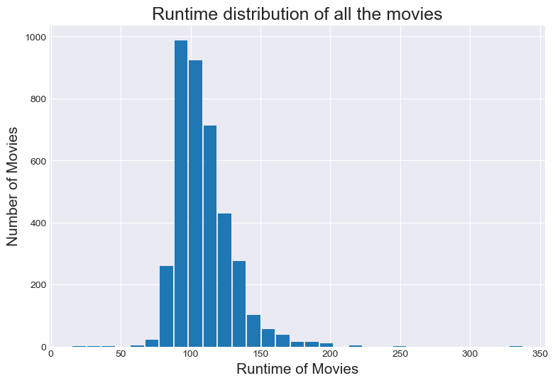

```python
#plotting a histogram of runtime of movies

#gives styles to bg plot
sns.set_style('darkgrid')

#changing the label size, this will change the size of all plots that we plot from now!
plt.rc('xtick', labelsize = 10)
plt.rc('ytick', labelsize = 10)

plt.figure(figsize=(9,6), dpi = 100)    #giving the figure size(width, height)
plt.xlabel('Runtime of Movies', fontsize = 15)   #x-axis label name
plt.ylabel('Number of Movies', fontsize=15)    #y-axis label name
plt.title('Runtime distribution of all the movies', fontsize=18)    #title of the graph

plt.hist(movie_data['runtime'], rwidth = 0.9, bins =31)    #giving a histogram plot
plt.show()    #displays the plot
```

The above graph shows us that how many movies lie between the time interval x1 to x2. For example, as you can see the tallest bar here is time interval between 85-100 min(approx) and around 1000 movies out of 3855 movies have the runtime between these time intervals. So we can also say from this graph that mode time of movies is around 85-110 min, has the highest concentration of data points around this time interval. The distribution of this graph is positively skewed or right skewed!

Let's dig deep and figure out the outliers of this distribution.

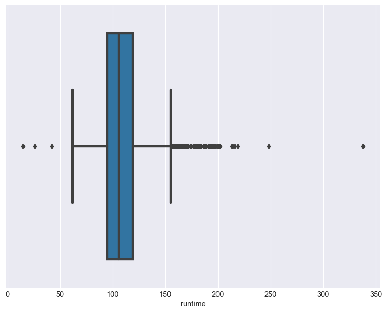

```python
#giving two plots, thr first is the box plot, second is plots of runtime for movies
plt.figure(figsize=(9,7), dpi = 105)    #giving figure size
sns.boxplot(movie_data['runtime'], linewidth = 3)   #using seaborn to plot box plot
plt.show()    #showing the plot1
```

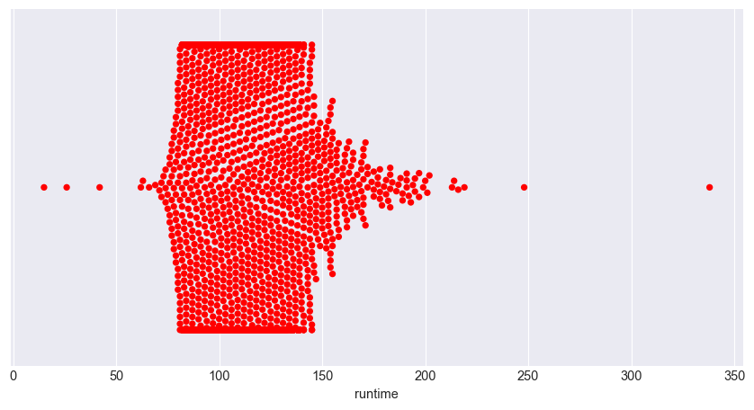

```python
#plots the data points of runtime of movies

#giving figure size
plt.figure(figsize=(10,5), dpi = 105)

sns.swarmplot(movie_data['runtime'], color = 'red')
plt.show()    #showing plot2
```

```python
#getting specific runtime points at x positions
movie_data['runtime'].describe()
```

```
count    3854.000000
mean      109.220291
std        19.922820
min        15.000000
25%        95.000000
50%       106.000000
75%       119.000000
max       338.000000
Name: runtime, dtype: float64
```

Both visualizations above shows us the overall distribution of runtime of movies by plotting the points where they lie in the ditribution and how many movies percent of movies lie below the runtime.

What's amazing about box-plot is that it gives us an overall idea of how spread the ditribution in our case the runtime of movies are. First of all what we get from this visualization is how many outliers we have, the min and max points, the median and IQR.

As we already saw in our previous calculations of least and highest runtime, this is the appropriate visualization in the comparison of other movies runtime. By looking at the box-plot we don't get the exact values but by giving the describe function above we get the exact values.

So by looking at both, visualiztions and calculations, we can say that..

As we can see there are more movies after the 3rd quartile range than the 1st. This makes the mean of the runtime pull towards the right or increases it.

Moving futher,

**Q1-F) In which year we had the most movies making profits?**

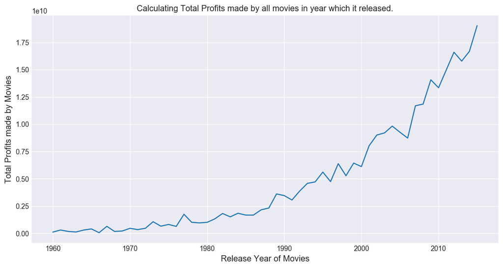

```python
#Line plot used for this
#Since we want to know the profits of movies for every year we need to group all the movies for those years

#the groupby function below collects all the movies for that year and then the profits of all those movies for that years is been added
#and storing all this in variable
profits_each_year = movie_data.groupby('release_year')['profit'].sum()
plt.figure(figsize=(12,6), dpi = 130)    #giving the figure size(width, height)

plt.xlabel('Release Year of Movies', fontsize = 12)    #labeling x-axis
plt.ylabel('Total Profits made by Movies', fontsize = 12)   #labeling y-axis
plt.title('Calculating Total Profits made by all movies in year which it released.')    #title of a the plot
plt.plot(profits_each_year)    #plotting what needs to be plotted
plt.show()    #showing the plot
```

Each values in the y-axis is been multiplied to `'1e10'` (as shown above the plot). Since the profits of movies are high, having 9+ digits, cannot fit the axis.

This dataset also doesn't show all the movies that has been released in each year. If it would the graph might would show some different trend.

For convenience, i have shown which year had the most profit. Also we will take a look at the profits of each year with exact figures.

```python
#shows which year made the highest profit
profits_each_year.idxmax()
```

```
2015
```

```python
#storing the values in the the form of DataFrame just to get a clean and better visual output
profits_each_year = pd.DataFrame(profits_each_year)
#printing out
profits_each_year.tail()
```

| release_year | profit |
| --- | --- |
| 2011 | 14966694704 |
| 2012 | 16596845507 |
| 2013 | 15782743325 |
| 2014 | 16676201357 |
| 2015 | 19032145273 |

`2015` was the year where movies made the highest profit of about `19+ billion dollars` which released in that year.

We are now done with exploring the dataset given. Next, we want to find similar characteristics of most profitable movies.

**Q2-A) Average runtime of successful movies**

Before answering this question, we need to first clean the dataset so we only have the data of movies that made profit not loss. Also we need movies not only who just made profit by some dollars but we need movies who made significant profits and then analyzing similar characteristics of it.

**Let's take only the movies who made profits of 50M dollars or more.**

```python
#assinging new dataframe which holds values only of movies having profit $100k or more
profit_movie_data = movie_data.query('profit >= 50000000')

#reindexing new dataframe
profit_movie_data.index = range(len(profit_movie_data))
#will initialize dataframe from 1 instead of 0
profit_movie_data.index = profit_movie_data.index + 1

#showing the dataset
profit_movie_data.head(2)
```

|  | budget_(in_US$) | revenue_(in_US$) | profit | original_title | cast | director | tagline | runtime | genres | release_date | release_year |
| --- | --- | --- | --- | --- | --- | --- | --- | --- | --- | --- | --- |
| 1 | 150000000 | 1513528810 | 1363528810 | Jurassic World | Chris Pratt\|Bryce Dallas Howard\|Irrfan Khan\|Vi... | Colin Trevorrow | The park is open. | 124 | Action\|Adventure\|Science Fiction\|Thriller | 2015-06-09 | 2015 |
| 2 | 150000000 | 378436354 | 228436354 | Mad Max: Fury Road | Tom Hardy\|Charlize Theron\|Hugh Keays-Byrne\|Nic... | George Miller | What a Lovely Day. | 120 | Action\|Adventure\|Science Fiction\|Thriller | 2015-05-13 | 2015 |

```python
#number of rows of a dataframe
len(profit_movie_data)
```

```
1338
```

```python
def prof_avg_fuc(column_name):
    return profit_movie_data[column_name].mean()
```

```python
#mean of runtime
prof_avg_fuc('runtime')
```

```
113.66741405082212
```

The mean time for movies making significant profits is likely similar to the mean runtime of movies that we found before of `109.2` which included movies having less than $50M profits. Difference is of 4 minutes.

**Q2-B) Average Budget of Movies**

```python
#calling the function
prof_avg_fuc('budget_(in_US$)')
```

```
60444957.76083707
```

The average budget of movies of $50M club in profit is around `$60M dollars`.

**Q2-C) Average Revenue of Movies**

```python
#calling the function
prof_avg_fuc('revenue_(in_US$)')
```

```
254957662.59491777
```

The average revenue of movies of $50M club in profit is around `$255M dollars`.

**Q2-D )Average Profit of Movies**

```python
#calling the function
prof_avg_fuc('profit')
```

```
194512704.83408073
```

The average profits of movies of $50M club in profit is around `$194M dollars`.

**Q2-E) Which directer directed most films?**

```python
#function which will take any column as argument from which data is need to be extracted and keep track of count
def extract_data(column_name):
    #will take a column, and separate the string by '|'
    all_data = profit_movie_data[column_name].str.cat(sep = '|')
    all_data = pd.Series(all_data.split('|'))    #giving pandas series and storing the values separately
    count = all_data.value_counts(ascending = False)    #this will us value in descending order

    return count
```

```python
#this variable will store the return value from a function
director_count = extract_data('director')
#shwoing top 5 values
director_count.head()
```

```
Steven Spielberg    23
Robert Zemeckis     13
Clint Eastwood      12
Tim Burton          11
Tony Scott          10
dtype: int64
```

`'Steven Spielberg'` takes the crown! Directing `23 movies` over `$50M+` in profit is no joke! Also the other directors following along the list such as `'Robert Zemeckis', 'Clint Eastwood', 'Tim Burton' etc` prove to be really great directors. Movies directed by these directors is more likely for a movie to make huge profits, the higher the movies they direct that earn huge profits, the higher the probability for a movie to go for success! Since we don't really know how many movies the directors directed in total in their lifetime, we can't say for sure that movies directed by above directors will always earn this much but gives us the idea that how much likely it is when it is directed by them.

**Q2-F) Whcih cast has appeared the most?**

```python
#this will variable will store the return value from a function
cast_count = extract_data('cast')
#shwoing top 5 values
cast_count.head()
```

```
Tom Cruise            27
Brad Pitt             25
Tom Hanks             22
Sylvester Stallone    21
Cameron Diaz          20
dtype: int64
```

**Q2-G) Which genre were more successful?**

```python
#this will variable will store the return value from a function
genre_count = extract_data('genres')
#shwoing top 5 values
genre_count.head()
```

```
Comedy       492
Drama        481
Action       464
Thriller     405
Adventure    379
dtype: int64
```

Lets visualize this with a plot.

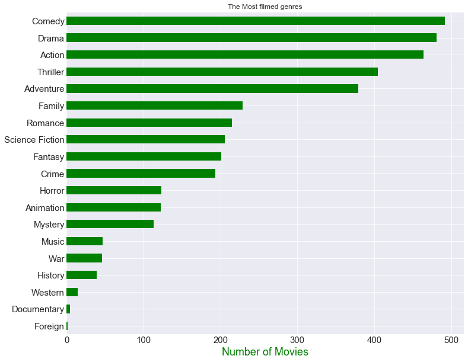

```python
#we want plot to plot points in descending order top to bottom
#since our count is in descending order and graph plot points from bottom to top, our graph will be in ascending order form top to bottom
#hence lets give the series in ascending order
genre_count.sort_values(ascending = True, inplace = True)

ax = genre_count.plot.barh(color = 'green', fontsize = 15)    #initializing plot
ax.figure.set_size_inches(12, 10)    #giving the figure size(width, height)
ax.set_xlabel('Number of Movies', color = 'g', fontsize = '18')    #x-label
ax.set(title = 'The Most filmed genres')    #giving a title

#shwoing the plot
plt.show()
```

So, `Action, Drama and Comedy genres` are the most as visualized but Comedy takes the prize, about `492 movies` have genres comedy which make $50M+ in profit. In comparison, even `Adventure` and `Thriller` really play the role. These five genres have more number of movies than rest of the genres as shown by visualization. Probability of earning more than \$50M for these genres are higher, but still other genres do count too again it depends on lots of other influential factors that come in play. `Western, war, history, music, documentary` and the most least `foreign` genres have less probability to make this much in profit as in comparison to other genre.

This also doesn't prove that if you have a movie with an `Action, comedy and drama` genre in it will have a guarantee to make more than $50M but it would have a significant interest and attraction to the population.

**Q2-H) Which month released highest number of movies in all of the years? And which month made the most profit?**

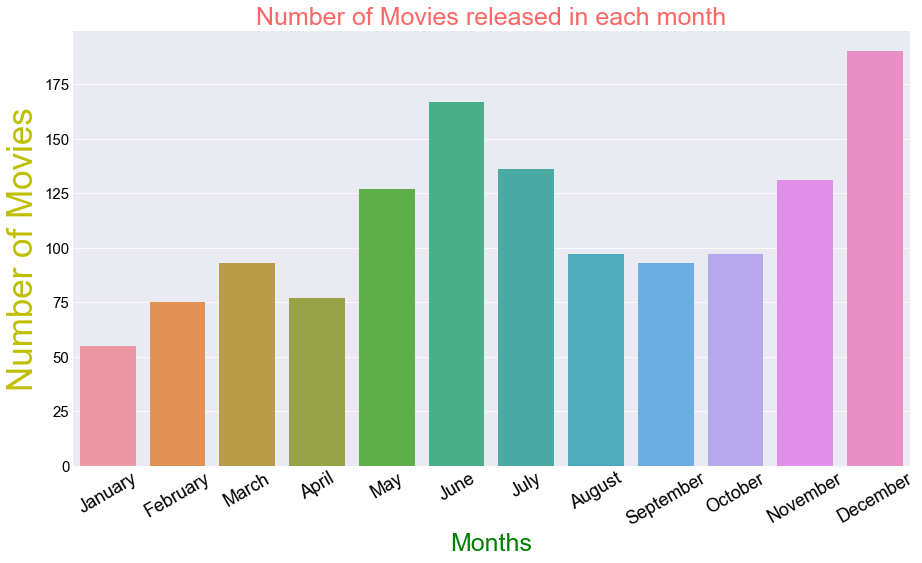

```python
#for answering this question we need to group all of the months of years and then calculate the profits of those months
#giving a new dataframe which gives 'release-date' as index
index_release_date = profit_movie_data.set_index('release_date')

#now we need to group all the data by month, since release date is in form of index, we extract month from it
groupby_index = index_release_date.groupby([(index_release_date.index.month)])

#this will give us how many movies are released in each month
monthly_movie_count = groupby_index.profit.count()

#converting table to a dataframe
monthly_movie_count= pd.DataFrame(monthly_movie_count)

#list of months
month_list = ['January', 'February', 'March', 'April', 'May', 'June', 'July', 'August', 'September', 'October', 'November', 'December']

monthly_movie_count_bar = sns.barplot(x = monthly_movie_count.index, y = monthly_movie_count.profit, data = monthly_movie_count)

#setting size of the graph
monthly_movie_count_bar.figure.set_size_inches(15,8)

#setting the title and customizing
monthly_movie_count_bar.axes.set_title('Number of Movies released in each month', color="r", fontsize = 25, alpha = 0.6)
monthly_movie_count_bar.set_xlabel("Months", color="g", fontsize = 25)    #setting x-label
monthly_movie_count_bar.set_ylabel("Number of Movies", color="y", fontsize = 35)    #setting y-label

#customizing axes values
monthly_movie_count_bar.tick_params(labelsize = 15, labelcolor="black")

#rotating the x-axis values to make it readable
monthly_movie_count_bar.set_xticklabels(month_list, rotation = 30, size = 18)
#display
plt.show()
```

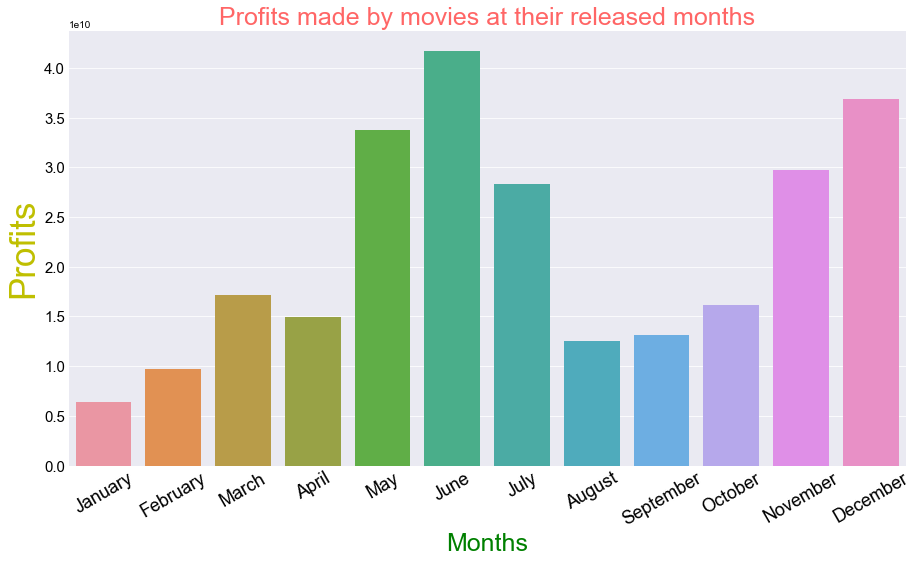

```python
#finding the second part of this question

#now since the data is grouped by month, we add 'profit' values to respective months, saving all this to a new variable
monthly_profit = groupby_index.profit.sum()

#converting table to a dataframe
monthly_profit = pd.DataFrame(monthly_profit)

#giving seaborn bar plot to visualize the data
#giving values to our graph
monthly_profit_bar = sns.barplot(x = monthly_profit.index, y = monthly_profit.profit, data = monthly_profit)

#setting size of the graph
monthly_profit_bar.figure.set_size_inches(15,8)

#setting the title and customizing
monthly_profit_bar.axes.set_title('Profits made by movies at their released months', color="r", fontsize = 25, alpha = 0.6)

#setting x-label
monthly_profit_bar.set_xlabel("Months", color="g", fontsize = 25)
#setting y-label
monthly_profit_bar.set_ylabel("Profits", color="y", fontsize = 35)

#customizing axes values
monthly_profit_bar.tick_params(labelsize = 15, labelcolor="black")

#rotating the x-axis values to make it readable
monthly_profit_bar.set_xticklabels(month_list, rotation = 30, size = 18)

#shows the plot
plt.show()
```

Seeing the both visualizations of both graphs we see similar trend. Where there are more movie released there is more profit and vice versa but just not for one month i.e `December`. December is the month where most movie release but when compared to profits it ranks second. This means that december month has high release rate but less profit margin. The month of June where we have around `165 movie` releases, which is second highest, is the highest in terms of making profits.

Also one more thing is we earlier finded which movie had made the most profit in our dataset, We came up with the answer of movie, `'Avatar'`, and the release month for this movie is in december, also the highest in loss movie had also released in december but that isn't being counted here. Knowing this that you have the highest release rate and highest profit making movie in same month of `December` but falls short in front of `June` month in terms of making profits makes me think that the month of June had movies with significant high profits where in december it didn't had that much high, making it short in terms of profit even though having the advantage of highest release rate.

This visualization doesn't prove us that if we release a movie in those months we will earn more $50M. It just makes us think that the chances are higher, again it depends on other influential factors, such as directors, story, cast etc.

## Conclusion

If one who wants to show one of the best and most profitable movie, he can:

[output not shown]

**-Choose these genre** - Action, Adventure, thriller, Comedy, Drama.

**-Choose these release months** - May, June, July, November, December.

## Reference

- [About pandas dataframes](https://pandas.pydata.org/pandas-docs/stable/generated/pandas.DataFrame.html)
- [About pandas visualization](http://pandas.pydata.org/pandas-docs/stable/visualization.html#visualization)
- [About TMDb](https://www.themoviedb.org/about?language=en)
- [Dataset download link](https://www.google.com/url?q=https://d17h27t6h515a5.cloudfront.net/topher/2017/October/59dd1c4c_tmdb-movies/tmdb-movies.csv&sa=D&ust=1520456065743000&usg=AFQjCNE04YzC40qAErEhbIdpbYEsN6oVKA)
- [Pandas Drop.Duplicate](https://pandas.pydata.org/pandas-docs/stable/generated/pandas.DataFrame.drop_duplicates.html)
- [Stackoverflow](https://stackoverflow.com/questions/48066517/python-pandas-pd-read-excel-giving-importerror-install-xlrd-0-9-0-for-excel)